# Practicum 1

Dominique Schreiner

7/5/2021

```r
rm(list=ls())
```

The libraries to support my functions created throughout this project.

```r
library(readr)
library(dplyr)
library(RMySQL)
```

```r
library(ggplot2)
library(lubridate)
```

Loading the CSV file

```r
BirdStrikesData <- read_csv("BirdStrikesData.csv")
```

Select and rename columns

```r
BirdStrikesNew = BirdStrikesData %>% select(`Airport: Name`, `Wildlife: Number Struck Actual`, FlightDate, `Aircraft: Airline/Operator`, `When: Phase of flight`)

names(BirdStrikesNew) = c("Airport", "StrikeNum", "FlightDate", "Airline", "FlightPhase")
```

Cleanup dataset

```r
BirdStrikesNew = BirdStrikesNew %>% filter(is.na(Airport) == FALSE)
```

Create Year column

```r
lst = strsplit(BirdStrikesNew$FlightDate, "/")
nlst = length(lst)

unlst = unlist(lst)

Year = vector(length=nlst)

for(i in 1:nlst) {

  year = unlst[i*3]
  year = strsplit(year, " ")
  year = year[[1]][1]
  year = as.Date(year, "%Y")
  Year[i] = year

}

class(Year) = "Date"

BirdStrikesNew$Year = Year
```

Creating DataSet to use for FlightPhase Table = FlightPhaseDF

```r
FlightPhase = unique(BirdStrikesNew$FlightPhase)
n = length(FlightPhase)
PhaseID = c(1:n)

FlightPhaseDF = data.frame(PhaseID = PhaseID,
                           PhaseName = FlightPhase)
```

Creating DataSet to use for Airline Table = AirlineDF

```r
airlineName = unique(BirdStrikesNew$Airline)
n = length(airlineName)
airlineID = c(1:n)

AirlineDF = data.frame(airlineID = airlineID,
                           airlineName = airlineName)
```

Creating DataSet to use for Airport Table = AirportDF

```r
airportName = unique(BirdStrikesNew$Airport)
n = length(airportName)
airportID = c(1:n)

AirportDF = data.frame(airportID = airportID,
                           airportName = airportName)
```

# DB Settings to provide connection to my cloud server. I chose to use AWS.

```r
db_user <- 'admin'
db_password <- 'CS5200_Sum21'
db_name <- 'practicum1'
db_host <- 'practicum1.ccjlbposbfqr.us-east-2.rds.amazonaws.com'
db_port <- 3306

# Connect to db
mydb <-  dbConnect(MySQL(), user = db_user, password = db_password, database = db_name, host = db_host, port = db_port)
```

Selecting the Schema to Use

```sql
USE practicum1;
```

Below are the queries to create tables in my schema. I used the following queires, drop table if exits, followed by create, and then writing the table.

```sql
DROP TABLE IF EXISTS
BirdStrikeIncident;
```

```sql
DROP TABLE IF EXISTS
Airline;
```

```sql
CREATE TABLE Airline (
airlineID INT NOT NULL,
airlineName VARCHAR(50),
PRIMARY KEY (airlineID)
);
```

```r
RMySQL::dbWriteTable(mydb, "airline", AirlineDF,
                     append=F, overwrite = T, row.names=FALSE)
```

```
## [1] TRUE
```

```sql
SELECT * FROM Airline
LIMIT 5
```

0 records

| airlineID | airlineName |
| --- | --- |

```sql
SELECT count(*) FROM Airline
```

1 records

| count(*) |
| --- |
| 0 |

```sql
DROP TABLE IF EXISTS
Airport;
```

```sql
CREATE TABLE Airport (
airportID  INT NOT NULL,
airportName VARCHAR(255),
PRIMARY KEY (airportID)
);
```

```r
RMySQL::dbWriteTable(mydb, "airport", AirportDF,
                     append=F, overwrite = T, row.names=FALSE)
```

```
## [1] TRUE
```

```sql
SELECT * FROM Airport
LIMIT 5
```

0 records

| airportID | airportName |
| --- | --- |

```sql
SELECT count(*) FROM Airport
```

1 records

| count(*) |
| --- |
| 0 |

```sql
DROP TABLE IF EXISTS FlightPhase;
```

```sql
CREATE TABLE FlightPhase
(PhaseID INT NOT NULL,
 PhaseName VARCHAR(20),
 PRIMARY KEY (PhaseID)
)
```

```r
RMySQL::dbWriteTable(mydb, "flightphase", FlightPhaseDF,
                     append=F, overwrite = T, row.names=FALSE)
```

```
## [1] TRUE
```

```sql
select * from flightphase
LIMIT 7
```

7 records

| PhaseID | PhaseName |
| --- | --- |
| 1 | Climb |
| 2 | Landing Roll |
| 3 | Approach |
| 4 | Take-off run |
| 5 | Descent |
| 6 | Taxi |
| 7 | Parked |

```sql
SELECT count(*) FROM flightphase
```

1 records

| count(*) |
| --- |
| 7 |

Creating DataFrame for birdStrikeIncident Table = birdStrikesDF

```r
birdStrikesDF = BirdStrikesNew %>% select(Year, StrikeNum)
n = nrow(birdStrikesDF)

airportID = vector(length = n)
airlineID = vector(length = n)
phaseID = vector(length = n)

for (i in 1:n) {

  obs = BirdStrikesNew[i,]

  Airport = obs$Airport
  Airport_ind = which(AirportDF$airportName == Airport)
  airportID[i] = AirportDF$airportID[Airport_ind]

  # print(airportID[i])

  Airline = obs$Airline
  Airline_ind = which(AirlineDF$airlineName == Airline)
  airlineID[i] = AirlineDF$airlineID[Airline_ind]

  # print(airlineID[i])

  FlightPhase = obs$FlightPhase
  Phase_ind = which(FlightPhaseDF$PhaseName == FlightPhase)
  phaseID[i] = FlightPhaseDF$PhaseID[Phase_ind]

  # print(phaseID[i])

}

birdStrikesDF$airportID = airportID
birdStrikesDF$airlineID = airlineID
birdStrikesDF$phaseID = phaseID

head(birdStrikesDF)
```

| Year | StrikeNum | airportID | airlineID | phaseID |
| --- | --- | --- | --- | --- |
| 2000-07-08 | 859 | 1 | 1 | 1 |
| 2001-07-08 | 424 | 2 | 2 | 2 |
| 2001-07-08 | 261 | 3 | 3 | 3 |
| 2002-07-08 | 806 | 4 | 4 | 1 |
| 2003-07-08 | 942 | 5 | 5 | 3 |
| 2003-07-08 | 537 | 6 | 2 | 4 |

```sql
DROP TABLE IF EXISTS
birdstrikeincident;
```

```sql
CREATE TABLE birdstrikeincident (
Year DATE NOT NULL,
StrikeNum INT NOT NULL,
airportID  INT NOT NULL,
airlineID INT NOT NULL,
phaseID INT NOT NULL,
PRIMARY KEY (airportID, airlineID),
FOREIGN KEY (airportID) REFERENCES Airport (airportID),
FOREIGN KEY (airlineID) REFERENCES Airline (airlineID),
FOREIGN KEY (phaseID) REFERENCES FlightPhase (phaseID)
);
```

```r
RMySQL::dbWriteTable(mydb, "birdstrikeincident", birdStrikesDF,
                     append=F, overwrite = T, row.names=FALSE)
```

```
## [1] TRUE
```

```sql
SELECT * FROM birdstrikeincident
LIMIT 5;
```

5 records

| Year | StrikeNum | airportID | airlineID | phaseID |
| --- | --- | --- | --- | --- |
| 2000-07-08 | 859 | 1 | 1 | 1 |
| 2001-07-08 | 424 | 2 | 2 | 2 |
| 2001-07-08 | 261 | 3 | 3 | 3 |
| 2002-07-08 | 806 | 4 | 4 | 1 |
| 2003-07-08 | 942 | 5 | 5 | 3 |

```sql
SELECT COUNT(*) FROM birdstrikeincident
```

1 records

| COUNT(*) |
| --- |
| 25429 |

Task 4: find the number of bird strike incidents for each airline upon take-off or climb

```sql
SELECT phaseID, airlineID, COUNT(StrikeNum)
FROM birdstrikeincident
WHERE phaseID = '1'
OR phaseID ='4'
GROUP BY airlineID;
```

Displaying records 1 - 10

| phaseID | airlineID | COUNT(StrikeNum) |
| --- | --- | --- |
| 1 | 1 | 343 |
| 1 | 4 | 87 |
| 4 | 2 | 771 |
| 1 | 3 | 1287 |
| 4 | 7 | 170 |
| 4 | 12 | 124 |
| 1 | 6 | 192 |
| 1 | 13 | 517 |
| 1 | 15 | 87 |
| 1 | 16 | 99 |

Task 5: to find the airports that had the most bird strike incidents

```sql
SELECT airlineID, airportID, SUM(StrikeNum), phaseID
FROM birdstrikeincident
GROUP BY airportID
ORDER BY SUM(StrikeNum) DESC;
```

Displaying records 1 - 10

| airlineID | airportID | SUM(StrikeNum) | phaseID |
| --- | --- | --- | --- |
| 2 | 2 | 2933 | 2 |
| 3 | 106 | 1856 | 1 |
| 1 | 1 | 1579 | 1 |
| 2 | 52 | 1396 | 3 |
| 13 | 91 | 1376 | 3 |
| 17 | 35 | 1210 | 4 |
| 47 | 107 | 1207 | 4 |
| 4 | 4 | 1181 | 1 |
| 5 | 5 | 1119 | 3 |
| 6 | 68 | 1027 | 1 |

Task 6: to find the number of bird strike incidents by year

```sql
SELECT year(Year), SUM(StrikeNum), airlineID
FROM birdstrikeincident
GROUP BY Year
ORDER BY SUM(StrikeNum) DESC;
```

Displaying records 1 - 10

| year(Year) | SUM(StrikeNum) | airlineID |
| --- | --- | --- |
| 2010 | 7657 | 2 |
| 2009 | 7169 | 39 |
| 2011 | 7105 | 3 |
| 2003 | 6193 | 5 |
| 2006 | 5839 | 6 |
| 2002 | 5505 | 4 |
| 2008 | 5350 | 29 |
| 2005 | 5138 | 29 |
| 2007 | 5069 | 20 |
| 2001 | 4721 | 2 |

Task 7 Creating DataFrame to Plot

```r
BarChartDF = BirdStrikesNew %>%
  filter(year(Year) %in% c(2008:2011) &
           FlightPhase != 'Parked' & FlightPhase != 'Taxi')

BarChartDF = BarChartDF %>%
  mutate(
    Year = year(Year),
    GRP=ifelse(FlightPhase=='Take-off run' | FlightPhase=='Climb', 'TC', 'ADL'),
  ) %>% select(Year, GRP, StrikeNum)
```

Cleaning Up The Year Format for Year Column The GRP is the groups of flight phase: whether it is on the ascent or descent off the trip. I classified Approach, Descent, Landing to be during the descent phase of a flight and is represented by ADL. I classified Climb and Take-Off Run to be during the ascent phase of a flight and is reprsented by TC.

```r
BarChartDF = BarChartDF %>% group_by(Year, GRP) %>%
  summarise(StrikeNum = sum(StrikeNum), .groups='keep')
BarChartDF = as.data.frame(BarChartDF)
BarChartDF
```

| Year | GRP | StrikeNum |
| --- | --- | --- |
| 2008 | ADL | 3229 |
| 2008 | TC | 2112 |
| 2009 | ADL | 4212 |
| 2009 | TC | 2945 |
| 2010 | ADL | 4771 |
| 2010 | TC | 2880 |
| 2011 | ADL | 4433 |
| 2011 | TC | 2661 |

Displaying As Stacked

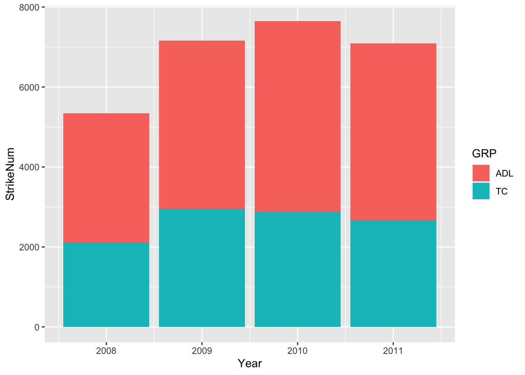

```r
# Stacked
ggplot(BarChartDF, aes(fill=GRP, y=StrikeNum, x=Year)) +
    geom_bar(position="stack", stat="identity")
```

Displayed as dual columns stacked side by side.

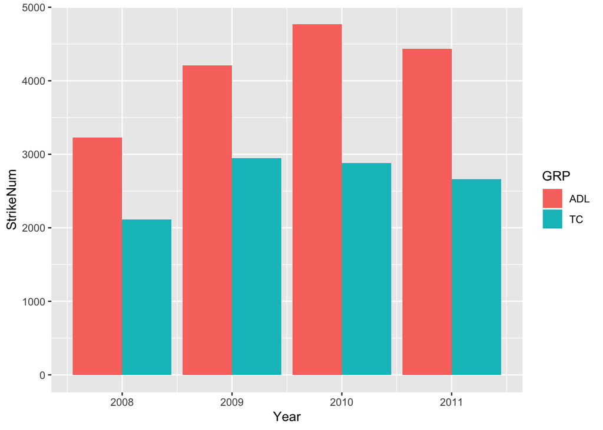

```r
# SideBySide
ggplot(BarChartDF, aes(fill=GRP, y=StrikeNum, x=Year)) +
    geom_bar(position="dodge", stat="identity")
```

Task 8: removes a bird strike incident from the database I created this in MySQL workbench and it does work here, however the following code chunk to execute the stored procedure in R was prohibiting the generation of the knitted HTML. So I commented it out. Below is the call function displaying it deletes bird strike incident.

```sql
CALL sp_DeleteIncident ('ALASKA AIRLINES');
```

1 records

| airlineIDOut |
| --- |
| 4 |

```r
# query <-
# "
# DROP PROCEDURE IF EXISTS sp_DeleteIncident;
#
# CREATE DEFINER=`root`@`localhost` PROCEDURE `sp_DeleteIncident`(IN airlineNameIn varchar(50))
#
# BEGIN
# DECLARE airlineIDOut INT;
#
# select airlineID INTO airlineIDOut from airline
# where airlineName = airlineNameIn;
#
# delete from BirdStrikeIncident
# where airlineID = airlineIDOut;
#
# END
# "
#
#
# dbGetQuery(mydb, "select * from airline")
#
# res = sendQuery <- dbSendQuery(mydb, "select * from airline")
# data <- dbFetch(res, n = 2)
# data
#
# ## sendQuery <- dbSendQuery(mydb, query)
# dbClearResult(dbListResults(mydb)[[1]])
```